# Themes and citation conversations in Defence and Peace Economics

A research note on the 1997–2026 catalogue

Published

15 October 2026

Abstract

What has Defence and Peace Economics published about, and how do its papers build on one another? This note answers those questions in two ways. First, a computer groups article summaries, known as abstracts, by similarities in their language. Second, it maps citations: references from one paper to another. The analysis uses a fixed copy of a catalogue containing 1,221 records from 1997 to 2026. The model finds ten themes in the 1,152 available abstracts, leaving uncertain cases unassigned. The 1,143 papers selected for citation analysis have 3,097 links between them. The results broadly support three published reviews of the journal’s history, especially their accounts of the growing importance of conflict, economic growth and terrorism. The citation map also reveals more specific groups, such as papers about why governments spend on defence and how that spending relates to public debt. Following Delahais and Thyrard’s study of the journal Evaluation, these groups are treated as possible research conversations that require closer reading. Missing early articles, abstracts and references limit what can be concluded. The two methods provide complementary views: what papers discuss, and which other papers they refer to.

# 1 Introduction

There is more than one way to tell the story of a research journal. Editors can look back and identify its major subjects. A computer can group papers whose language is similar. References can show which earlier papers authors draw on. These approaches need not produce the same groups. Papers may discuss similar subjects without citing one another, while a paper about economic growth may cite work on government debt.

*Defence and Peace Economics* (DPE) has published three retrospectives: reviews of its first, second and third decades (Hartley and Sandler 2000; Arce and Kollias 2010; Gaibulloev, Kollias, and Solomon 2020). This note compares those accounts with two existing computer analyses of the journal. A **topic model** groups papers by similarities in their abstracts, the short summaries that accompany articles. A **citation network** connects papers when one refers to another. The questions are straightforward: which subjects recur, how has their share of the journal changed, and do papers about similar subjects also form groups linked by references?

The idea of a research conversation comes from Delahais and Thyrard (2026). Their study of *Evaluation* uses citations to find groups of papers, then examines what those papers actually say. This distinction is essential. A reference may acknowledge background work, adopt a method, support an argument or criticise a finding. A link alone cannot tell us which. In this note, citation groups identify promising places to look for a conversation; they do not prove that a debate took place.

# 2 What the analysis covers and how it works

## 2.1 The papers included

The analysis uses a fixed copy of the data saved on 15 October 2026. Its source is Research Papers in Economics (RePEc), a service that records information about economics publications. The copy contains 1,221 journal records dated 1997 to 2026, including volume 37 through issue 6. Of these records, 1,152 include an abstract and 69 do not. The listed years are publication dates recorded in the catalogue; they do not mean that every year, especially 2026, is complete. This manuscript explains an existing analysis rather than training a new model.

The comparisons involve three different sets of papers. The topic model uses papers with abstracts. The citation network includes 1,143 research articles and reviews containing substantive analysis. It excludes 78 records, mainly administrative material, issue introductions, routine book notices and corrections, using recorded title rules and individual review decisions. A paper can enter the citation network even if its abstract is missing. Finally, each historical retrospective uses its own set of published papers. Counts from these three sources therefore cannot always be compared directly.

Table 1: Papers available for each historical comparison. Review count is the number classified by the editors, excluding separately listed book reviews; catalogue is all available records; the abstracts column counts records with a summary; no topic counts summaries the model left unassigned. The first review covers volumes 1-10 through volume 10, issue 2, but the catalogue starts at volume 8. The second covers volumes 11-20 and the third volumes 21-30.

| Review period | Review count | Catalogue | Abstracts | No topic |
| --- | --- | --- | --- | --- |
| First decade (partial) | 207 | 48 | 45 | 2 |
| Second decade | 331 | 361 | 330 | 34 |
| Third decade | 389 | 407 | 381 | 23 |

The periods in Table 1 follow journal volumes and issues. The first retrospective covers volumes 1 to 10, stopping at volume 10, issue 2. Our catalogue begins at volume 8, leaving only 45 abstracts to compare with the retrospective’s 207 classified papers. The second and third periods are much better covered, although the sets of included papers still differ. Book reviews listed separately in the retrospectives are not included in their classification totals.

There are also small differences between the published historical tables. The first retrospective lists five arms-trade papers, while a later table repeats the count as six. We use the original figures and its total of 207 papers, rather than the 208 reported in the third retrospective’s historical comparison (Hartley and Sandler 2000, 4–6; Gaibulloev, Kollias, and Solomon 2020, table 1).

## 2.2 Finding themes in the abstracts

The topic model first turns each abstract into a list of numbers that represents its language. Abstracts with similar meanings should have similar numerical descriptions. It then groups abstracts that lie close together in this numerical representation and picks words and phrases that help describe each group. Such a group is called a **cluster**. The words help explain what the computer found; they are not a list of subjects supplied in advance.

The software uses the BERTopic method, which separates the task of grouping texts from the task of describing their topics (Grootendorst 2022). To check the topic names, we read the keywords and three representative abstracts from each of the ten groups. For example, a group whose papers repeatedly connect military expenditure with national output is labelled military spending and economic growth. Here, economic growth means an increase in the amount an economy produces.

The model learned its groups from 1,138 abstracts among 1,207 records. The final two issues, with seven papers each, were kept out of that stage. The developers compared 54 combinations of settings and preferred those that produced at least ten topics. That preference helped separate smaller subjects, but it also influenced the result: ten topics should not be read as ten natural divisions in the field.

Some abstracts did not fit a group clearly. These are called **unassigned** abstracts. A second step assigned some of them only when they were sufficiently similar to one topic and clearly less similar to the next-best choice. In the training data, this reduced the unassigned count from 220 to 80. The resulting groups covered more papers and had more closely associated keywords, but were less clearly separated from one another. The change improved some measures, not all of them.

Papers added later were compared with the existing groups rather than used to rebuild them. This preserves earlier assignments, but cannot discover a new topic. In a test using 120 papers kept aside for checking this assignment rule, 116 received a topic; 95.7% of those assignments agreed with the model’s original labels. This measures consistency with the model, not accuracy against an independent human judgement.

The current data contain 1,070 abstracts assigned to topics and 82 left unassigned. Every abstract was processed in full. The appendix records the software, settings and numerical checks for readers who want to reproduce the analysis.

## 2.3 Connecting papers through their references

The citation network contains a connection whenever an included paper cites another included paper. References come from Crossref, an organisation through which publishers register publication details and reference lists. A **digital object identifier (DOI)** is a persistent identifier for a publication. The analysis checks these identifiers against the papers’ recorded details. Where a reference lacks a usable DOI, it can still be matched if its publication details identify one paper exactly or a reviewer confirms the match. Approximate text matches are not accepted automatically. Repeated references from one paper to the same other paper count as one connection.

The next step finds **citation communities**: groups of papers with more connections within the group than would be expected from their overall pattern of connections. The method groups papers using whether they are connected, without distinguishing which paper cited which. Citation direction is retained for other counts, such as how often a paper is cited. Papers with no recorded connection to another included paper are called **isolates** and remain outside the communities.

The software’s grouping rules were checked using alternative settings, and its main result was compared with one based only on DOI matches. These checks show how much the groups can change when the method changes. The drawing of the network is a separate step: a paper’s position on the page is a visual aid, not a measurement of its importance or a statement that nearby papers necessarily agree.

This approach follows the direct-citation idea used by Delahais and Thyrard (2026): connect papers through their actual references to one another. Their study starts from Scopus, a different publication database, and reads the resulting groups to assess their meaning. Our network is limited to papers in the DPE catalogue and does not measure citations from elsewhere. Its group names are working descriptions, based on the existing labels and evidence from leading papers, and remain provisional. Small groups are retained rather than discarded simply because they are difficult to summarise.

# 3 How the themes compare with the three retrospectives

## 3.1 The overall picture

Conflict, war and peace is the largest topic, followed by military spending and economic growth, then terrorism and counterterrorism, meaning efforts to prevent or respond to terrorist attacks. Together these three topics contain 596 abstracts, or 51.7% of those available (Table 2).

Several other labels need explanation. **Procurement** means purchasing equipment and services, here for defence. **Alliances** are arrangements in which countries cooperate on security. **Military personnel** covers the people who serve, including questions about recruitment and former service members, or veterans. **Geopolitical risk** means uncertainty or danger arising from political developments and relations between countries; the corresponding topic focuses on financial markets’ responses. **Public debt** is money owed by government. An **arms race** is a competitive build-up of weapons by rivals.

Table 2: How the 1,152 available abstracts are divided among topics. Percentages include abstracts with no assigned topic, but exclude the 69 records without abstracts.

| Topic | Abstracts | Share (%) |
| --- | --- | --- |
| Conflict, war and peace | 241 | 20.9 |
| Military spending and economic growth | 218 | 18.9 |
| Terrorism and counterterrorism | 137 | 11.9 |
| Defence industries and procurement | 125 | 10.9 |
| Defence spending and alliances | 117 | 10.2 |
| Military personnel, recruitment and veterans | 73 | 6.3 |
| Arms trade and arms races | 57 | 4.9 |
| Geopolitical risk and financial markets | 41 | 3.6 |
| Military equipment costs | 36 | 3.1 |
| Military spending and public debt | 25 | 2.2 |
| No topic assigned | 82 | 7.1 |

Each assigned abstract receives one topic, even when the paper addresses several subjects. A subject can also appear within a larger topic without becoming a group of its own. The lack of a separate topic therefore does not show that the journal ignored that subject.

To compare the model with the retrospectives, we created a **crosswalk**, a table showing which of the editors’ categories overlap with which model topics. We rebuilt it using the current keywords and all 30 representative abstracts because the earlier comparison used an older model. For example, the spending-and-alliances topic includes studies of why governments choose particular spending levels. It is broader than the editors’ alliances category. Likewise, the model’s geopolitical-markets topic covers only part of the editors’ wider security category.

The full comparison table records the original counts, source locations and reasons for each match. A model topic can appear against more than one editorial category, so its counts must not be added across rows. The selected comparisons in Table 3 are guides to overlapping subjects, not checks that humans and the computer assigned each individual paper to the same category.

Table 3: Selected subjects: each cell shows the review count / model count. The reviews classify 207, 331 and 389 papers; the model uses 45, 330 and 381 abstracts. First-decade coverage is incomplete. A dash means the review has no separate category. The subjects overlap but differ: the first review combines terrorism with guerrilla warfare and armed rebellions; model conflict includes peace, alliances includes reasons for defence spending, industry includes purchasing, and personnel includes veterans. Matching totals do not prove that the same papers were selected.

| Theme | First decade | Second decade | Third decade |
| --- | --- | --- | --- |
| Growth | 9 / 10 | 56 / 62 | 65 / 90 |
| Terrorism | 11 / 0 | 37 / 37 | 55 / 56 |
| Conflict | — / 4 | 29 / 51 | 70 / 84 |
| Alliances | 18 / 11 | 20 / 45 | 9 / 27 |
| Industry | 16 / 15 | 25 / 39 | 15 / 22 |
| Personnel | 14 / 0 | 14 / 19 | 29 / 32 |

## 3.2 First decade: similar concerns, but much of the evidence is missing

Hartley and Sandler emphasise defence spending, procurement, alliances, industrial structure and **conversion**, the shift of resources or production from military to civilian uses. Their defence-spending category covers effects on the wider economy, patterns over time and explanations of how much governments spend. Those questions are spread across the model’s growth, spending-and-alliances and debt topics. Procurement also overlaps with defence industry, while conversion has no separate model topic (Hartley and Sandler 2000, 4–6).

Of the 45 available abstracts from this first period, 15 concern industry and procurement (33.3%), 11 spending and alliances (24.4%), and ten growth (22.2%). These findings show that some of the editors’ main concerns also appear in the available texts. They cannot establish how common those subjects were throughout the 1990s, because most of the retrospective’s period is missing.

The terrorism comparison makes this limitation clear. None of the 45 abstracts is assigned to the terrorism topic, yet the retrospective lists 11 papers under terrorism, guerrilla warfare and insurgencies, or armed rebellions. The findings are not necessarily contradictory. Most papers from the editors’ period are absent from our data, and their combined category covers more than the model’s terrorism topic.

Some editorial categories also answer different questions from a topic model. A country survey describes the kind of article, while a developing-country study identifies its geographical focus. Either could discuss industry, growth, alliances or conflict. The model groups papers by subject and need not reproduce these categories. The first retrospective is therefore most useful for identifying long-standing interests, rather than testing the computer’s classification.

## 3.3 Second decade: growth, terrorism and conflict become prominent

For volumes 11 to 20, Arce and Kollias identify defence and the economy as the largest category, followed by terrorism, with conflict and civil wars also prominent. The model assigns 62 abstracts to growth (18.8%), 51 to conflict (15.5%) and 37 to terrorism (11.2%). The editors’ counts are 56, 29 and 37 respectively, out of 331 classified papers (Arce and Kollias 2010, table I).

The identical terrorism counts do not establish that the same 37 papers were selected. The model has 330 abstracts in this period, and no independent comparison has checked both classifications paper by paper. The same total could result from different memberships.

The broader meaning of the model’s conflict topic helps explain its larger count. The editors separate conflict and civil wars from peace and peacekeeping; the model combines conflict, war and peace. Its representative papers examine matters such as civil-war risk, struggles over resources and links between economic conditions and conflict. Similarly, the model’s spending-and-alliances group has 45 abstracts, compared with 20 papers in the editorial alliances category, because the model also includes explanations of national defence spending. These differences do not make either classification inherently better.

Arce and Kollias relate the rise of terrorism research to changes in the security environment, including the attacks of 11 September 2001 (Arce and Kollias 2010, 398–99). The model’s results are consistent with that account: terrorism rises from three of 162 abstracts in 2000-2004 to 34 of 168 in 2005-2009. But the pattern does not prove that one event caused the increase. Delays between research and publication, special issues and the availability of new data may also have mattered.

## 3.4 Third decade and the years that follow

Gaibulloev, Kollias and Solomon report that conflict, defence and the economy, and terrorism together account for 190 of 389 papers, or 48.8%. In the corresponding model period, growth contributes 90 abstracts, conflict 84 and terrorism 56: together 230 of 381, or 60.4%. Both accounts identify these as leading subjects. Their different shares reflect differences in the papers included, the breadth of the categories and the decision to use a model with ten topics (Gaibulloev, Kollias, and Solomon 2020, tables 1-2).

Other changes point in similar directions. Between the second and third periods, military personnel rises from 5.8% to 8.4% of abstracts. Industry and procurement falls from 11.8% to 5.8%, and spending and alliances from 13.6% to 7.1%. The retrospective likewise records more papers on personnel and fewer on the defence industry and alliances. Yet the model’s equipment-cost topic rises from eight abstracts to 19. Separating equipment costs from industry as a whole makes a smaller, continuing research interest easier to see.

The third retrospective adds a security category that includes geopolitical risks and **sanctions**, restrictions intended to put pressure on a country or other target (Gaibulloev, Kollias, and Solomon 2020). The model divides these subjects. Geopolitical risk and financial markets form one topic, while sanctions appear among the conflict topic’s keywords. Only six abstracts from the third period belong to geopolitical markets, followed by 25 in 2020-2024 and nine in the available 2025-2026 records. This points to later interest in how markets respond to political risk, rather than recovery of the editors’ entire security category.

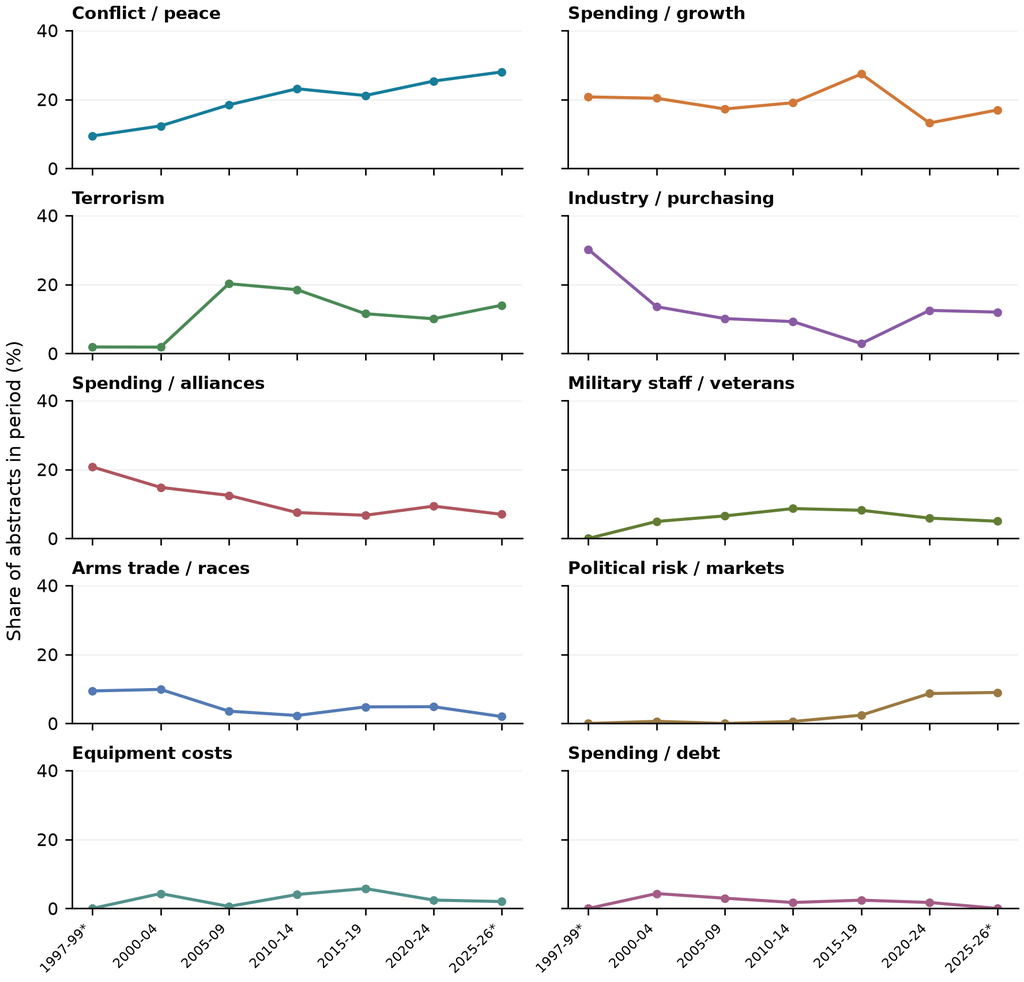

Figure 1: How each topic’s share changes over time. Each percentage uses all available abstracts in that period, including those without an assigned topic. The first and last periods, marked with an asterisk, are shorter: 1997-1999 and the available 2025-2026 records. These calendar-year periods differ from the volume-and-issue periods used by the retrospectives. Connecting lines help readers follow the pattern; they do not supply estimates for individual years.

The later data also show a renewed share for industry and sustained attention to conflict (Figure 1). These comparisons use the same topic model throughout. They show how a common set of categories describes the available papers, not how researchers at the time necessarily understood their field. A model trained separately on each decade might draw different boundaries.

# 4 What the citation connections add

## 4.1 A map of connected research

Among the 1,143 included papers, the network records 3,097 citations from one included paper to another. In total, 955 papers have at least one connection and 188 (16.4%) are isolates. The largest connected set contains 896 papers (78.4% of all included papers): each can be reached from another by following a chain of connections, ignoring the direction of the references.

The main grouping produces 36 communities. Twelve contain at least 15 papers; the others are smaller groups and remain part of the analysis. The largest concern growth (139 papers), industry and procurement (135), terrorism (134), explanations of defence spending (117), arms and technology (81), political risk and resources (71), and debt and budgets (70). The figures number these groups for convenience; the numbers are not permanent identities.

Of the 3,097 citation links, 2,514 (81.2%) connect papers within the same community. That is partly what the method is designed to find. It cannot be used as independent proof that researchers work in closed groups. Links across communities also matter: growth and public debt do not become separate intellectual worlds just because the computer puts them in different groups.

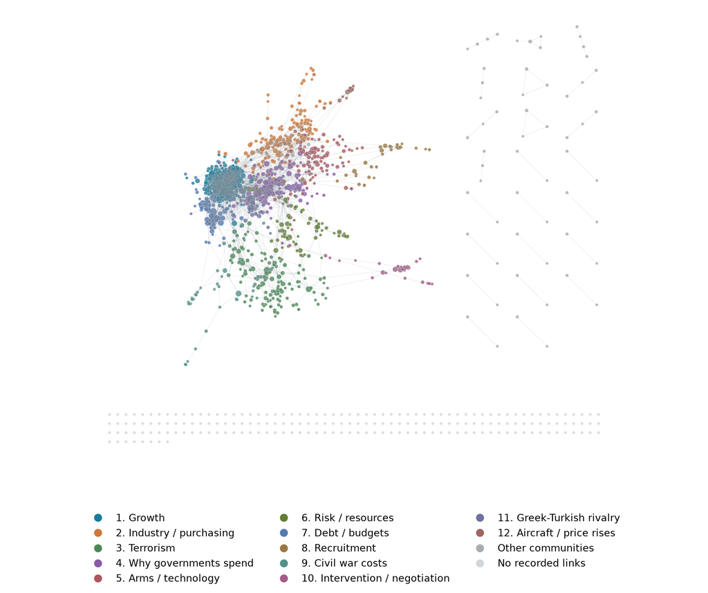

Figure 2: The citation map. Each dot is a paper and each line is a recorded reference between two included papers. A larger dot means that more included papers cite it. Colours identify the twelve largest citation communities; smaller communities are grey, and papers with no recorded internal connections are light grey. Arrows are omitted to keep the picture readable. Small disconnected groups are placed on the right and isolates below; their distances from other groups have no interpretive meaning.

The precise boundaries depend on the evidence and settings. Using only DOI matches gives 3,093 links and 34 communities, compared with 3,097 links and 36 communities in the main result. Just four additional connections can therefore accompany changes in the grouping. A separate check changes **resolution**, the setting that controls how finely the network is divided. Lower and higher settings produce 31 and 41 communities. These are different levels of detail, not simply successful or failed versions of one true classification. The appendix reports the numerical comparisons.

## 4.2 Similar subjects do not always mean the same conversation

The comparison between topics and citation communities shows where the two methods agree (Figure 3). Of 139 papers in the growth community, 121 (87.1%) also belong to the growth topic. In the recruitment community, 32 of 37 papers (86.5%) belong to the personnel topic. Here, the language of abstracts and the pattern of references tell much the same story, although neither match is complete.

Other groups show why it helps to use both methods. The debt-and-budgets community contains 31 papers from the growth topic and 23 from the debt topic. References connect papers whose summaries emphasise different aspects of government finances. The community studying why governments spend on defence combines 66 spending-and-alliances papers with 24 growth papers.

The reverse also happens: one broad topic spreads across several citation communities. The conflict topic contributes 31 of 36 papers in a group about the costs of civil war, and 29 of 30 in a group about intervention and bargaining, meaning outside involvement in conflicts and negotiation between their participants. The topic model places these papers under one broad subject. Their references suggest more specific lines of research within it.

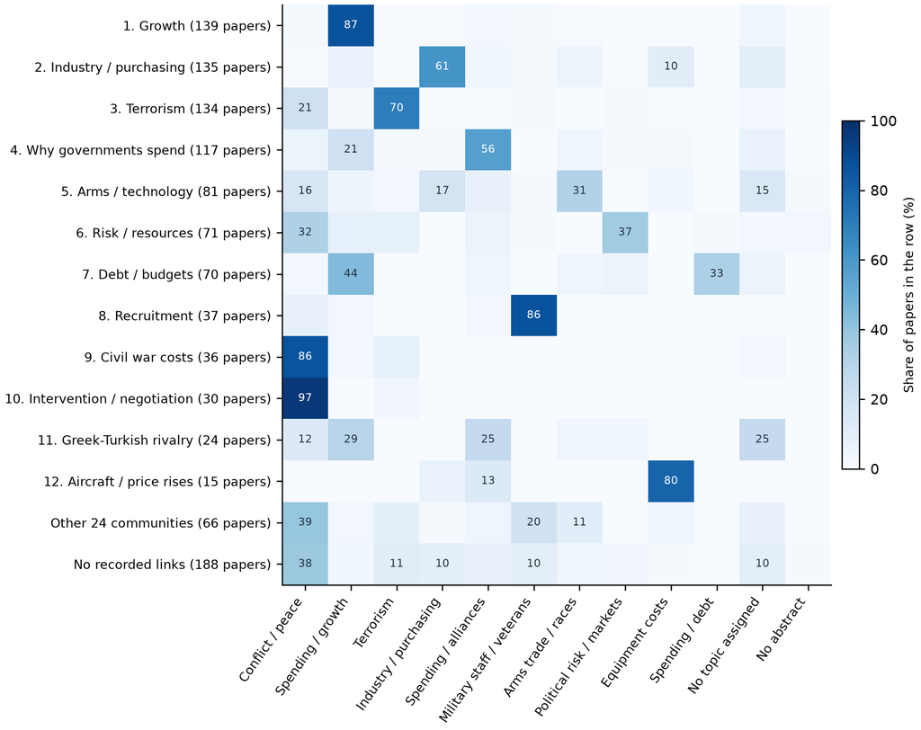

Figure 3: How topics are distributed within citation communities. Each row represents a community, and the percentages across that row add to 100%, including papers with unassigned or missing abstracts. Darker shading means a larger share. Numbers are printed only for shares of at least 10% and are rounded to whole percentages. The twelve largest communities have separate rows; the other 24 share a display row without being merged in the analysis. The number of papers in each row is shown in brackets.

This is the practical value of treating citation groups as possible conversations. As Delahais and Thyrard (2026) argue, a group needs to be interpreted by reading its papers, and a subject can cross group boundaries. For DPE, the results suggest questions for that closer reading. Do papers explaining defence spending use similar ways of analysing data? Do intervention studies ask different questions from studies of the costs of conflict? Titles, abstracts and citation links make these reasonable possibilities. They do not establish the purpose or tone of every reference, or prove that each community contains a sustained debate.

# 5 What we can and cannot conclude

The three approaches give a broadly consistent account of a journal that retains its traditional defence questions while giving greater attention to conflict and terrorism. Each approach also preserves something the others may miss. The retrospectives draw on expert knowledge and distinguish forms of work such as country surveys. The topic model applies the same language-based categories across the available years and separates smaller subjects such as equipment costs and debt. The citation network shows where references connect or divide those subjects.

Four limitations are particularly important. First, the catalogue starts in 1997. It cannot reconstruct the journal’s full first decade, and references to earlier papers cannot become connections in this network.

Second, missing abstracts and missing reference lists cause different gaps. Of the 1,143 papers included in citation analysis, 1,083 have references recorded by Crossref and 60 do not. All 30 included papers from 2002 and 23 of 30 from 2003 lack such lists. Other papers can still cite them, but their own missing references may change the apparent communities. An isolate has no recorded connection *within these data*; it need not be uncited or intellectually isolated.

Third, the map excludes papers outside the catalogue, including articles in other journals. It cannot show DPE’s full influence or all of its connections to neighbouring fields. Recent papers have also had less time to receive citations. A larger dot in the map means more citations from included papers at this date, not necessarily greater quality or importance.

Fourth, the computer’s choices influence its findings. Preferring at least ten topics encourages smaller groups. Assigning each paper to only one topic hides some overlap. Keeping the groups fixed when new papers arrive prevents the discovery of new topics. The numerical checks show that boundaries are not always sharp, and changing the citation settings changes the communities. Reading representative abstracts helps us name the topics, but does not replace an independent check of individual papers. The citation community names require still more reading before they can support claims about particular debates.

The conclusion is therefore limited but useful. In the available catalogue, the themes broadly support the later retrospectives’ emphasis on growth, conflict and terrorism. The citation links add a more detailed view of which papers draw on one another. A stronger follow-up would recover more early articles and missing references, ask readers to classify individual papers, and examine the passages where citations occur. That would test the interpretations directly, rather than assuming that agreement between two computer summaries makes them correct.

# How to reproduce the results

The accompanying files contain the editable manuscript, its references, the fixed evidence, the category comparison table and a Python program that produces the figures and tables. The manuscript uses Quarto, software for turning text and analysis into documents, and BibTeX, a structured format for storing references. Reproducing the note does not require retraining the model or downloading current data.

The files also contain **checksums**, digital fingerprints used to check that a file has not changed. These connect the saved evidence to the original analysis and reference documents. The scripts check paper counts, citation counts, repeated links and the composition of each group. They retain the totals used to calculate every percentage. Full copies of the reference papers are not redistributed. Delahais and Thyrard is cited under its 2026 journal issue year; the bibliography also records its online publication in December 2025.

# Technical appendix: settings and checks

This appendix preserves the detail needed to repeat or assess the calculations. The main findings do not depend on understanding every setting.

## How the topic model represents and groups text

An **embedding** is a numerical representation of a text’s meaning, stored as a **vector**, or ordered list of numbers. The model uses Qwen3-Embedding-0.6B, a language model designed to produce these representations (Zhang et al. 2025). Each vector is normalised, meaning rescaled to the same length so that comparisons focus on its direction. **Cosine similarity** compares these directions; a larger value indicates greater similarity in this representation. The exact software revision is recorded in the files documenting the analysis.

**UMAP**, short for Uniform Manifold Approximation and Projection, reduces the number of coordinates used to describe each abstract while trying to preserve nearby relationships (McInnes, Healy, and Melville 2018). **HDBSCAN**, Hierarchical Density-Based Spatial Clustering of Applications with Noise, then finds dense groups of abstracts and allows others to remain unassigned (McInnes, Healy, and Astels 2017). These tools supply the grouping stage of BERTopic. To describe the resulting topics, **class-based TF-IDF** (term frequency-inverse document frequency) gives more weight to words that are common within a topic but less widespread across topics. It uses single words and two-word phrases, removes common English words such as “the”, and reduces the influence of very frequent words.

The 54 settings combinations used UMAP neighbourhood sizes of 10, 20 or 40 and five or ten dimensions, meaning coordinates per abstract. HDBSCAN minimum group sizes were 20, 35 or 50, and its minimum-samples setting, which influences how dense an area must be to form a group, was one, three or five. The selected settings were 40 neighbours, five dimensions, minimum group size 20 and minimum samples five.

UMAP used cosine distance, a measure of difference derived from cosine similarity, and a minimum-distance setting of zero. HDBSCAN used **Euclidean distance**, ordinary straight-line distance in the reduced numerical space, and its **excess-of-mass** rule, which favours groups that remain stable across density levels. The two-dimensional topic map is a separate drawing; it was not used to form the five-dimensional groups.

## Choosing settings and assigning later papers

Four checks contributed to the choice of model. **Coherence** measures how often a topic’s keywords occur together. **Silhouette** measures how much more closely a paper resembles its own group than other groups, here using the original embeddings and cosine distance. **Keyword diversity** is the share of distinct words and phrases among all the topic keywords. **Coverage** is the proportion of abstracts given a topic. Their scores were put on comparable scales across trials; coherence and silhouette each received twice the weight of diversity and coverage.

A **random seed** fixes the sequence used in a calculation with random steps, making a particular run repeatable. Configurations producing at least ten topics with seed 42 were preferred. The top three qualifying configurations were checked using seeds 42, 7 and 21; the average score selected the settings. Ties used **adjusted mutual information**, a measure of agreement between groupings that allows for agreement expected by chance. The final fit used seed 42.

Reassignment of initially unassigned abstracts required both sufficient similarity to the best topic and sufficient separation from the second choice. Against the initial, untuned model, coherence rose from 0.0899 to 0.1382 and coverage from 78.7% to 93.0%. Silhouette fell from 0.1046 to 0.0770; diversity remained 0.93. These are checks on the computer’s grouping, not tests of the historical interpretation.

Later papers were compared with fixed **centroids**, numerical centres summarising the topics. Assignment required cosine similarity of at least 0.475 and a difference of at least 0.02 between the best and second-best topics. **Calibration** means choosing these cutoffs by checking example assignments. For this check, 120 papers with confident topic assignments were set aside and did not contribute to the topic centres used to test them. The rule accepted 116 of these papers, with 95.7% agreement with their original model labels. This is the internal-consistency result described earlier, not a separate test against expert classifications.

## Grouping and drawing the citation network

In network terminology, a **node** is a paper and an **edge** is a citation link. The recorded links are **directed**, meaning they run from the citing paper to the cited paper. For grouping, the analysis uses an **undirected** version: it treats a connection as shared, adding the weights when two papers cite one another. Isolates receive no community assignment.

The **Louvain method** seeks groups with high **modularity**, a score comparing connections within groups with those expected in a network with a similar pattern of connections per paper (Blondel et al. 2008). The analysis tries 20 seeds, numbered 0 to 19, at resolution one. It selects the highest modularity, breaking ties with a fixed rule. This produces 36 communities and modularity of 0.6486.

The **adjusted Rand index** compares two sets of group memberships while allowing for chance agreement: one means identical groupings, and zero corresponds to chance-level agreement under its comparison model. On the same 955 connected papers, the DOI-only result has an index of 0.918 against the main result. At resolutions 0.5 and 1.5, the results have 31 and 41 communities and indices of 0.678 and 0.660. Modularity scores at different resolutions use different objectives, so their values are not directly comparable as measures of quality.

**ForceAtlas2** is the method used to arrange the network on the page (Jacomy et al. 2014). It uses forces resembling attraction and repulsion to position connected papers. The drawing uses seed 42 and 500 rounds of position updates within each connected component, meaning a set of papers joined by some chain of links. Separate components and isolates are positioned independently. Dot area grows linearly with **in-degree**, the number of included papers citing that paper, with a minimum size so that small dots remain visible. None of these drawing choices changes the recorded links or community memberships.

# References

Arce, Daniel, and Christos Kollias. 2010. ‘Defence and Peace Economics: The Second Decade in Retrospect’. *Defence and Peace Economics* 21 (5-6): 395–407. https://doi.org/10.1080/10242694.2010.512195.

Blondel, Vincent D., Jean-Loup Guillaume, Renaud Lambiotte, and Etienne Lefebvre. 2008. ‘Fast Unfolding of Communities in Large Networks’. *Journal of Statistical Mechanics: Theory and Experiment* 2008 (10): P10008. https://doi.org/10.1088/1742-5468/2008/10/P10008.

Delahais, Thomas, and Antonin Thyrard. 2026. ‘Conversations in Evaluation: Exploring 30 Years of Debates in Our Field’. *Evaluation* 32 (1): 11–36. https://doi.org/10.1177/13563890251406246.

Gaibulloev, Khusrav, Christos Kollias, and Binyam Solomon. 2020. ‘Defence and Peace Economics: The Third Decade in Retrospect’. *Defence and Peace Economics* 31 (4): 377–86. https://doi.org/10.1080/10242694.2020.1761221.

Grootendorst, Maarten. 2022. ‘BERTopic: Neural Topic Modeling with a Class-Based TF-IDF Procedure’. https://doi.org/10.48550/arXiv.2203.05794.

Hartley, Keith, and Todd Sandler. 2000. ‘Defence and Peace Economics: A Ten-Year Retrospective’. *Defence and Peace Economics* 11 (1): 1–16. https://doi.org/10.1080/10430710008404935.

Jacomy, Mathieu, Tommaso Venturini, Sebastien Heymann, and Mathieu Bastian. 2014. ‘ForceAtlas2, a Continuous Graph Layout Algorithm for Handy Network Visualization Designed for the Gephi Software’. *PLOS ONE* 9 (6): e98679. https://doi.org/10.1371/journal.pone.0098679.

McInnes, Leland, John Healy, and Steve Astels. 2017. ‘Hdbscan: Hierarchical Density Based Clustering’. *Journal of Open Source Software* 2 (11): 205. https://doi.org/10.21105/joss.00205.

McInnes, Leland, John Healy, and James Melville. 2018. ‘UMAP: Uniform Manifold Approximation and Projection for Dimension Reduction’. https://doi.org/10.48550/arXiv.1802.03426.

Zhang, Yanzhao, Mingxin Li, Dingkun Long, Xin Zhang, Huan Lin, Baosong Yang, Pengjun Xie, et al. 2025. ‘Qwen3 Embedding: Advancing Text Embedding and Reranking Through Foundation Models’. https://doi.org/10.48550/arXiv.2506.05176.